# Kümeleme Analizleri ve Uygulamaları

Ahu CEPHE, MsC.

15 Mayıs 2022

# KÜMELEME ANALİZLERİ

## Analiz Hazırlık Aşaması

### Kütüphanelerin Yüklenmesi

Kümeleme analizleri için kullanılacak olan kütüphaneler aşağıdaki kodlar çalıştırılarak yüklenir.

```r
library(dplyr)
library(magrittr)
library(ggplot2)
library(factoextra)
library(gridExtra)
library(ClusterR)
library(fpc)
library(cluster)
library(stringr)
library(GGally)
library(NbClust)
library(mclust)
library(clValid)
library(tidyverse)
library(dendextend)
```

### Veri Okuma

Kümeleme analizleri için **iris** veri seti kullanılacaktır. Veri setinin “sınıf” sütununu içermemesi için son sütunu veri setinden çıkartılacaktır. Bu veri seti, her bir türden 50 örnek olmak üzere üç farklı yaprak çeşidine (setosa, virginica ve versicolor) ait toplamda 150 örnek sayısına sahip bir veri setidir. Her bir örnek için taç yaprak uzunluğu (petal.lenght), taç yaprak genişliği (petal.width), çanak yaprak genişliği (sepal.width) ve çanak yaprak uzunluğu (sepal.lenght) olmak üzere dört özellik belirlenmiştir. Amacımız; bu dört özelliğe sahip 150 örnek veri setine kümeleme algoritmaları uygulayarak yaprak çeşitlerini (kümeleri) bulmak.

Kümeleme analizlerinde kullanılacak olan iris veri seti aşağıdaki kod ile değişkene atılabilir ve değişken türleri kontrol edebilebilir.

```r
# iris veri seti yüklenir
data <- iris[,-5]

# Veri setinin yapısı ve değişkenlerin veri türleri kontrol edilir
str(data)
```

```
## 'data.frame':    150 obs. of  4 variables:
##  $ Sepal.Length: num  5.1 4.9 4.7 4.6 5 5.4 4.6 5 4.4 4.9 ...
##  $ Sepal.Width : num  3.5 3 3.2 3.1 3.6 3.9 3.4 3.4 2.9 3.1 ...
##  $ Petal.Length: num  1.4 1.4 1.3 1.5 1.4 1.7 1.4 1.5 1.4 1.5 ...
##  $ Petal.Width : num  0.2 0.2 0.2 0.2 0.2 0.4 0.3 0.2 0.2 0.1 ...
```

Veri setindeki değişken isimleri, en üstten ve en alttan birkaç satır veriye ulaşmak için aşağıdaki kodlar kullanılır.

```r
# Değişken isimleri
names(data)
```

```
## [1] "Sepal.Length" "Sepal.Width"  "Petal.Length" "Petal.Width"
```

```r
# Veri setinde en üstten 5 satır döndürür
head(data)
```

```
##   Sepal.Length Sepal.Width Petal.Length Petal.Width
## 1          5.1         3.5          1.4         0.2
## 2          4.9         3.0          1.4         0.2
## 3          4.7         3.2          1.3         0.2
## 4          4.6         3.1          1.5         0.2
## 5          5.0         3.6          1.4         0.2
## 6          5.4         3.9          1.7         0.4
```

```r
# Veri setinde en alttan 5 satır döndürür
tail(data)
```

```
##     Sepal.Length Sepal.Width Petal.Length Petal.Width
## 145          6.7         3.3          5.7         2.5
## 146          6.7         3.0          5.2         2.3
## 147          6.3         2.5          5.0         1.9
## 148          6.5         3.0          5.2         2.0
## 149          6.2         3.4          5.4         2.3
## 150          5.9         3.0          5.1         1.8
```

Değişkenlerin tanımlayıcı istatistikleri görüntülenebilir.

```r
# Değişkenlerin tanımlayıcı istatistikleri
summary(data)
```

```
##   Sepal.Length    Sepal.Width     Petal.Length    Petal.Width
##  Min.   :4.300   Min.   :2.000   Min.   :1.000   Min.   :0.100
##  1st Qu.:5.100   1st Qu.:2.800   1st Qu.:1.600   1st Qu.:0.300
##  Median :5.800   Median :3.000   Median :4.350   Median :1.300
##  Mean   :5.843   Mean   :3.057   Mean   :3.758   Mean   :1.199
##  3rd Qu.:6.400   3rd Qu.:3.300   3rd Qu.:5.100   3rd Qu.:1.800
##  Max.   :7.900   Max.   :4.400   Max.   :6.900   Max.   :2.500
```

Veri setinde NA, NaN veya infinity değerler olup olmadığı kontrol edilir.

```r
# Toplam NA'lar
f <- function(x){sum(is.na(x))}
sapply(data,f)%>%as.data.frame()
```

```
##              .
## Sepal.Length 0
## Sepal.Width  0
## Petal.Length 0
## Petal.Width  0
```

```r
# Toplam infinite değerlerin kontrolü
f <- function(x){sum(is.infinite(x))}
sapply(data,f) %>% as.data.frame()
```

```
##              .
## Sepal.Length 0
## Sepal.Width  0
## Petal.Length 0
## Petal.Width  0
```

```r
# Toplam NaN değerleri
f <- function(x){sum(is.nan(x))}
sapply(data,f)%>%as.data.frame()
```

```
##              .
## Sepal.Length 0
## Sepal.Width  0
## Petal.Length 0
## Petal.Width  0
```

### Değişken Dağılımlarının İncelenmesi

Değişkenlerin dağılımları histogram grafikleri ile incelenebilir.

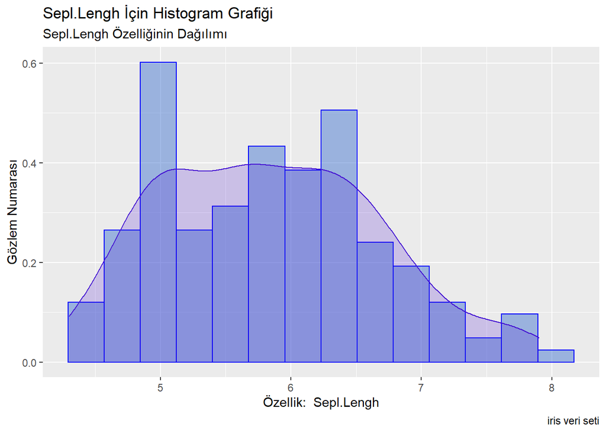

```r
# Histogram ve yoğunluk grafiği oluşturulur
histf<-function(z){
feature=str_replace_all(deparse(substitute(z)),"[data$]","")
ggplot(data) +
aes(x = z) +
geom_histogram(aes(y=..density..), position="identity", alpha=0.5,bins = 14L, fill = "#497AD2", colour = "blue") +
geom_density(alpha=0.2, fill = "#4411D2", colour = "#4411D2")+
labs(x =  paste("Özellik: ",feature),y = "Gözlem Numarası",
title = paste(feature, "İçin Histogram Grafiği"),
subtitle = paste(feature, "Özelliğinin Dağılımı"),
caption = "iris veri seti") +
theme_grey()
}

# 4 özellik için histogram grafikleri
histf(data$Sepal.Length)
```

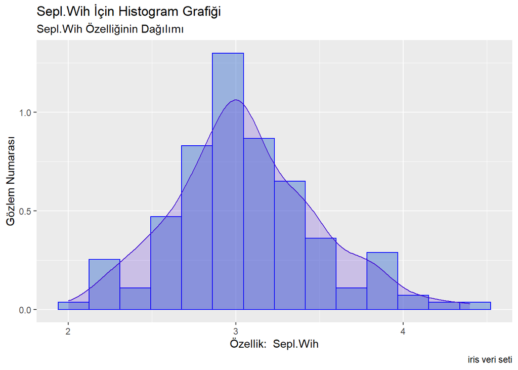

```r
histf(data$Sepal.Width)
```

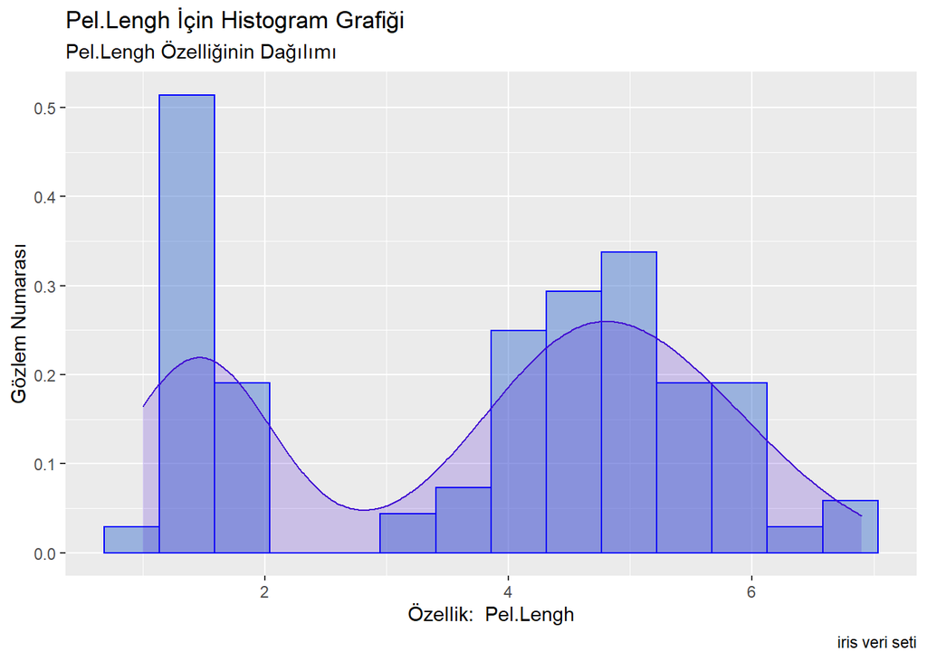

```r
histf(data$Petal.Length)
```

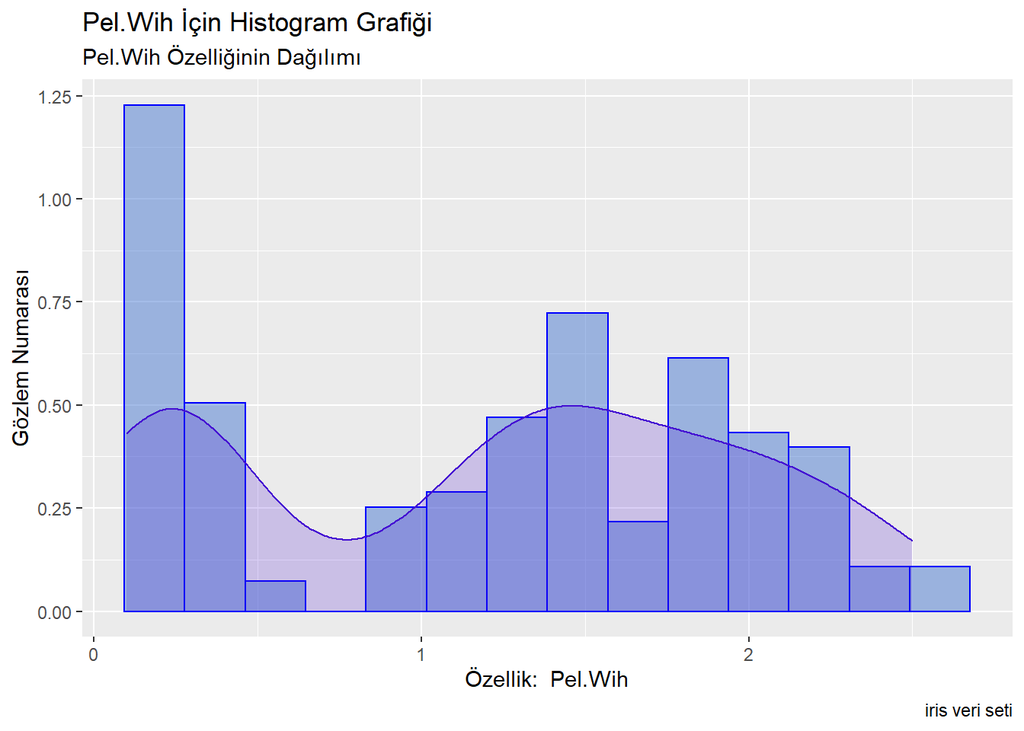

```r
histf(data$Petal.Width)
```

Histogram grafiklerini topluca görebilmek için ise aşağıdaki kod çalıştırılabilir.

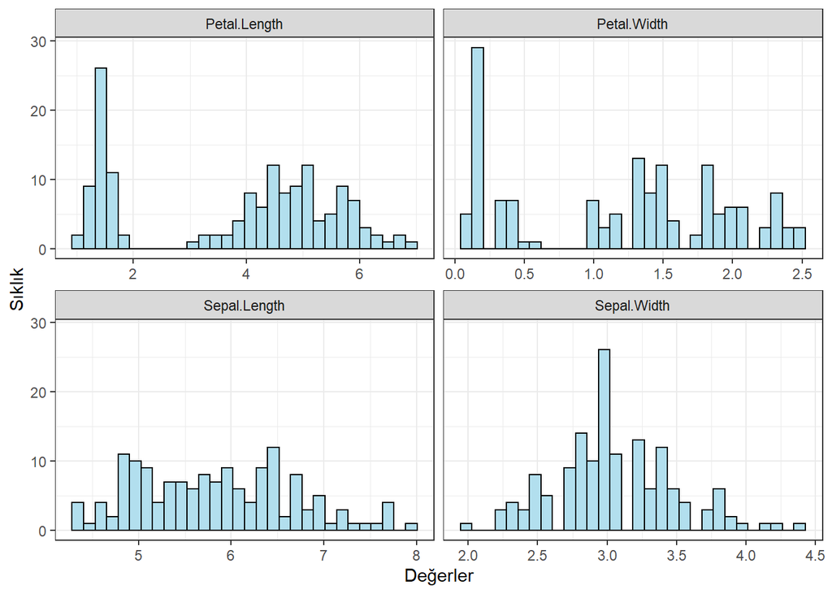

```r
iris1 <- as.data.frame(data)
iris1 %>%
  gather(attributes, value, 1:4) %>%
  ggplot(aes(x = value)) +
  geom_histogram(fill = 'lightblue2', color = 'black') +
  facet_wrap(~attributes, scales = 'free_x') +
  labs(x="Değerler", y="Sıklık") +
  theme_bw()
```

### Veri Standartlaştırma

Kümeleme analizlerinde verideki değişkenlerin birimlerinin incelenmesi ve eğer birim farklılığı varsa bu değişkenlerin standartlaştırılması gerekmektedir.

```r
# özelliklerin ortalaması
apply(data,2,mean) %>% as.data.frame()
```

```
##                     .
## Sepal.Length 5.843333
## Sepal.Width  3.057333
## Petal.Length 3.758000
## Petal.Width  1.199333
```

```r
# özelliklerin varyansı
apply(data,2,var)%>%as.data.frame()
```

```
##                      .
## Sepal.Length 0.6856935
## Sepal.Width  0.1899794
## Petal.Length 3.1162779
## Petal.Width  0.5810063
```

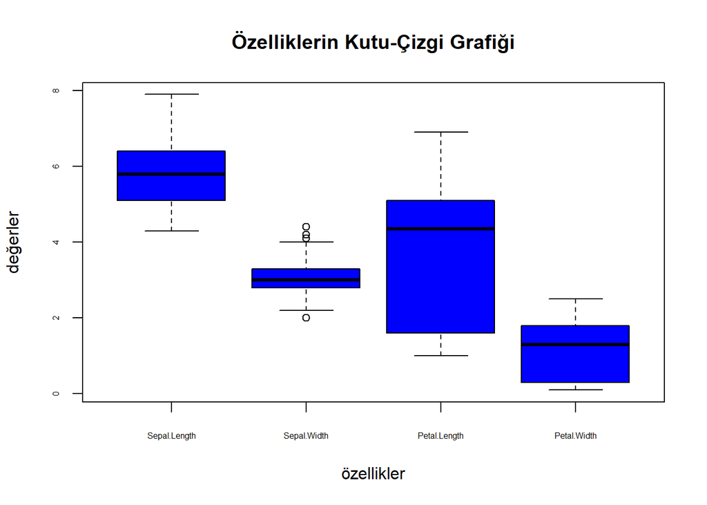

```r
# özelliklerin kutu-çizgi grafikleri
boxplot(data, xlab="özellikler",ylab="değerler", main ="Özelliklerin Kutu-Çizgi Grafiği", col = "blue",
        border = "black",cex.axis=.5)
```

Özelliklerin kümeleme algoritması uygulamak için iyi ölçeklenmediği görülüyor. Bu nedenle, her özelliğin ortalaması 0 ve standart sapması 1 olacak şekilde ölçeklenmeli.

```r
# veri setini standartlaştır
data.scaled <- scale(data)

# standartlaştırılmış verinin özeti
summary(data.scaled)
```

```
##   Sepal.Length       Sepal.Width       Petal.Length      Petal.Width
##  Min.   :-1.86378   Min.   :-2.4258   Min.   :-1.5623   Min.   :-1.4422
##  1st Qu.:-0.89767   1st Qu.:-0.5904   1st Qu.:-1.2225   1st Qu.:-1.1799
##  Median :-0.05233   Median :-0.1315   Median : 0.3354   Median : 0.1321
##  Mean   : 0.00000   Mean   : 0.0000   Mean   : 0.0000   Mean   : 0.0000
##  3rd Qu.: 0.67225   3rd Qu.: 0.5567   3rd Qu.: 0.7602   3rd Qu.: 0.7880
##  Max.   : 2.48370   Max.   : 3.0805   Max.   : 1.7799   Max.   : 1.7064
```

```r
# standartlaştırılmış verinin ortalaması
apply(data.scaled,2,mean)%>%as.data.frame()
```

```
##                          .
## Sepal.Length -4.484318e-16
## Sepal.Width   2.034094e-16
## Petal.Length -2.895326e-17
## Petal.Width  -3.663049e-17
```

```r
# standartlaştırılmış verinin varyansı
apply(data.scaled,2,var)%>%as.data.frame()
```

```
##              .
## Sepal.Length 1
## Sepal.Width  1
## Petal.Length 1
## Petal.Width  1
```

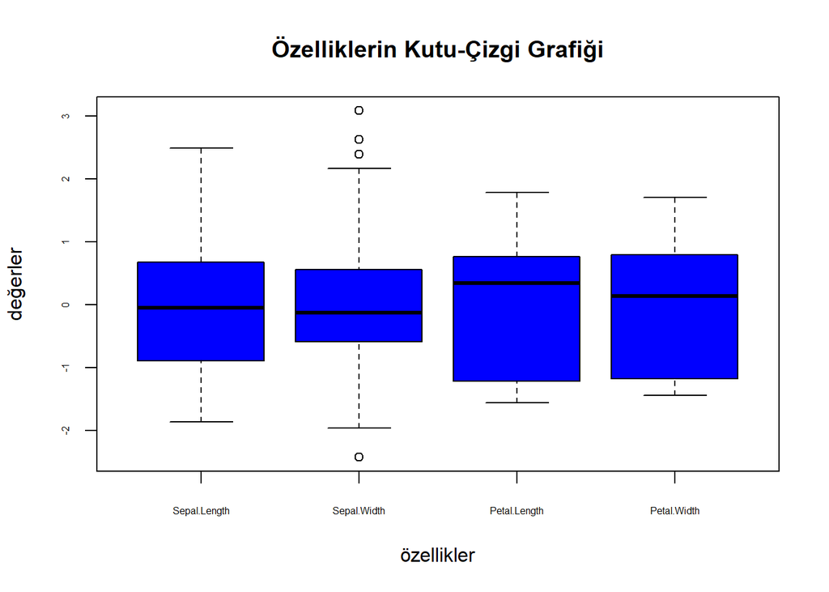

```r
# standartlaştırılmış özelliklerin kutu-çizgi grafikleri
boxplot(data.scaled, xlab="özellikler",ylab="değerler", main ="Özelliklerin Kutu-Çizgi Grafiği", col = "blue",border = "black",cex.axis=.5)
```